# Processing the FeatureCounts Data

Surya Vishnubhatt

2/26/23

```r
library(ggplot2)
library(tidyverse)
library(DESeq2)
library(vsn)
library(magrittr)
library(pheatmap)
library(EnhancedVolcano)
library(clusterProfiler)
library(org.Hs.eg.db)
```

# Preliminary Analysis of featureCounts Result

First, I was able to visualize the results from featureCounts by plotting the Assigned vs. Unassigned ratios as can be seen in Figure 2:

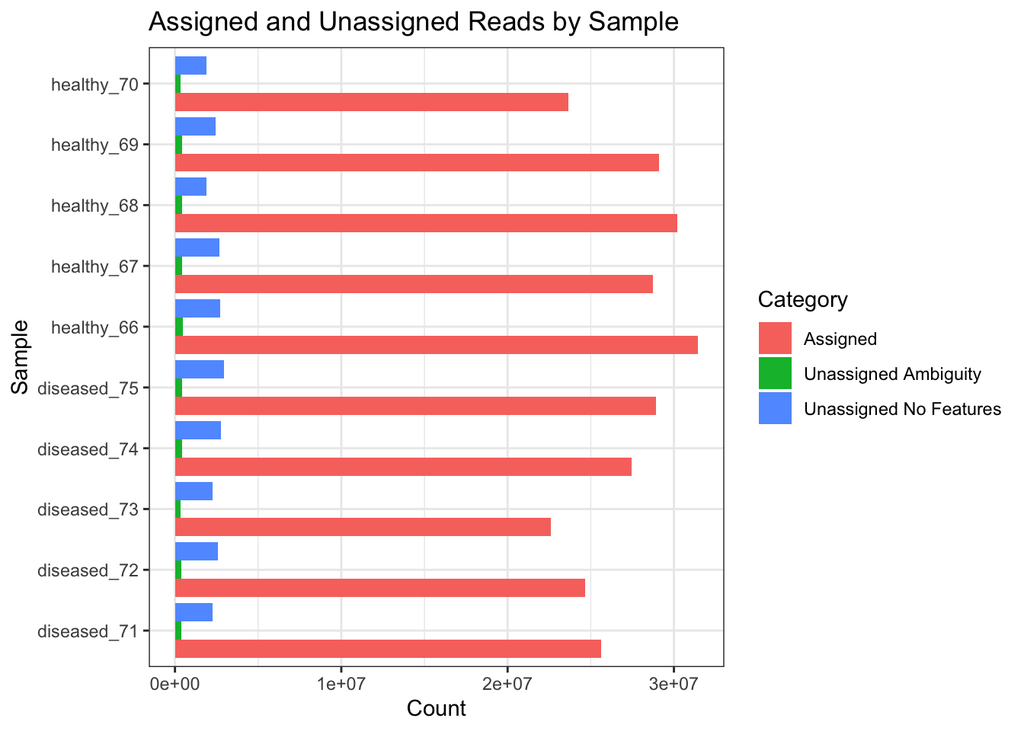

**Figure 2:** *Preliminary Analysis of featureCounts Result*

```r
# Load required packages
library(ggplot2)
# Read in the summary files
fc_summary <- read.table("~/Desktop/featurecounts_result/featureCounts.txt.summary", header=TRUE, row.names=1)
# Subset the data to only include the desired rows
fc_summary_subset <- fc_summary[c("Assigned", "Unassigned_Ambiguity", "Unassigned_NoFeatures"),]
fc_summary_subset_t <- data.frame(t(fc_summary_subset))

class_samples <- rep(c(66:75), 3)
category <- c(rep("Assigned", 10), rep("Unassigned Ambiguity", 10), rep("Unassigned No Features", 10))

# Create a new data frame with the desired order of categories
data <- data.frame(
  Sample = ifelse(class_samples <= 70, paste0("healthy_", class_samples), paste0("diseased_", class_samples)),
  Category = category,
  Count = c(fc_summary_subset_t$Assigned,
            fc_summary_subset_t$Unassigned_Ambiguity,
            fc_summary_subset_t$Unassigned_NoFeatures)
)

# Plot the data using ggplot2
ggplot(data, aes(x = Sample, y = Count, fill = Category)) +
  geom_bar(stat = "identity", position = "dodge") +
  xlab("Sample") +
  ylab("Count") +
  ggtitle("Assigned and Unassigned Reads by Sample") +
  theme_bw() +
  coord_flip() #rotate 90 degrees
```

As one can see, the plot details how the bulk of reads are assigned and shows the data is ready for downstream analysis. Note that the data above is labeled according to if they are the isogenic control (healthy) or if they exhibit the A79V mutation (diseased). The integer values following each healthy and diseased value correspond to the last two digits of their SRA accession number as they all contain the same first 10 values (i.e. SRR211907__).

# DESeq2 Object Setup

After performing this preliminary analysis, I loaded in the `featureCounts` table using `readcounts` and proceeded to manipulate the read count table. Such that it matches the parameters outlined above. I also made a few more tweaks such that gene IDs should be stored as row names and columns without read counts should be excluded. Finally, I created a new dataframe `sample_info` with the readcounts data and create the `colData` condition to keep track of the condition (healthy or diseased).

```r
# Load the featureCounts output file
folder <- "~/Desktop/featurecounts_result/" # download count table!
readcounts <- read.table(paste0(folder, "featureCounts.txt"), header = TRUE)
str(readcounts)
```

```
## 'data.frame':    59251 obs. of  16 variables:
##  $ Geneid                                                                              : chr  "TRNP" "TRNT" "CYTB" "TRNE" ...
##  $ Chr                                                                                 : chr  "chrM" "chrM" "chrM" "chrM" ...
##  $ Start                                                                               : chr  "15956" "15888" "14747" "14674" ...
##  $ End                                                                                 : chr  "16023" "15953" "15887" "14742" ...
##  $ Strand                                                                              : chr  "-" "+" "+" "-" ...
##  $ Length                                                                              : int  68 66 1141 69 525 1812 71 59 69 1378 ...
##  $ X.athena.angsd.scratch.spv4002.SRR21190766.SRR21190766.Aligned.sortedByCoord.out.bam: int  107 192 84208 25 2100 125232 2 0 5 160680 ...
##  $ X.athena.angsd.scratch.spv4002.SRR21190767.SRR21190767.Aligned.sortedByCoord.out.bam: int  94 149 81337 10 1696 107825 0 0 2 139417 ...
##  $ X.athena.angsd.scratch.spv4002.SRR21190768.SRR21190768.Aligned.sortedByCoord.out.bam: int  27 91 41596 4 830 53091 0 0 2 66163 ...
##  $ X.athena.angsd.scratch.spv4002.SRR21190769.SRR21190769.Aligned.sortedByCoord.out.bam: int  64 173 81309 21 1525 106494 2 0 2 139548 ...
##  $ X.athena.angsd.scratch.spv4002.SRR21190770.SRR21190770.Aligned.sortedByCoord.out.bam: int  54 174 71167 9 1405 111659 1 0 0 120339 ...
##  $ X.athena.angsd.scratch.spv4002.SRR21190771.SRR21190771.Aligned.sortedByCoord.out.bam: int  87 103 49835 10 1650 73828 0 0 3 96167 ...
##  $ X.athena.angsd.scratch.spv4002.SRR21190772.SRR21190772.Aligned.sortedByCoord.out.bam: int  60 117 49837 8 1336 80428 1 0 1 109725 ...
##  $ X.athena.angsd.scratch.spv4002.SRR21190773.SRR21190773.Aligned.sortedByCoord.out.bam: int  50 88 43398 8 1017 81417 1 0 4 106255 ...
##  $ X.athena.angsd.scratch.spv4002.SRR21190774.SRR21190774.Aligned.sortedByCoord.out.bam: int  51 121 45547 5 1223 81666 1 0 0 109272 ...
##  $ X.athena.angsd.scratch.spv4002.SRR21190775.SRR21190775.Aligned.sortedByCoord.out.bam: int  81 81 49032 10 1825 89945 0 0 3 113726 ...
```

```r
orig_names <- names(readcounts) # keep a back-up copy of the original names

#Rename to disease condition followed by patient number (last two digits of accession no. SRR211907__)
names(readcounts) <- c(names(readcounts)[1:6],
paste("healthy", c(66:70), sep = "_"),
paste("diseased", c(71:75), sep = "_") ) # less potential for typos
names(readcounts)
```

```
##  [1] "Geneid"      "Chr"         "Start"       "End"         "Strand"
##  [6] "Length"      "healthy_66"  "healthy_67"  "healthy_68"  "healthy_69"
## [11] "healthy_70"  "diseased_71" "diseased_72" "diseased_73" "diseased_74"
## [16] "diseased_75"
```

```r
## gene IDs should be stored as row.names
row.names(readcounts) <- make.names(readcounts$Geneid)
readcounts <- readcounts[ , -c(1:6)]

sample_info <- data.frame(condition = gsub("_[0-9]+", "", names(readcounts)),
row.names = names(readcounts) )

write.table(readcounts, file = "readcounts.txt", sep = "\t", row.names = TRUE, col.names = TRUE)
```

This data frame can then be used to generate the `DESeqDataSet` by loading in the readcounts, as a matrix, the colData (`sample_info`), and the `design = ~ condition`. This effectively creates our `DESeq.ds` object that will be implemented down the line. I then removed genes without reads and saw the number of genes decreased from 59251 to 37309 (see below). We can also note that there are now fewer features stored within the DESeq.ds object.

```r
DESeq.ds <- DESeqDataSetFromMatrix(countData = as.matrix(readcounts), colData = sample_info, design = ~ condition)

# Create the DESeq object
DESeq.ds <- DESeqDataSetFromMatrix(countData = as.matrix(readcounts),
                                   colData = sample_info,
                                   design = ~ condition)


#Remove genes with no reads
cat("Number of Genes Before:", dim(DESeq.ds))
```

```
## Number of Genes Before: 59251 10
```

```r
keep_genes <- rowSums(counts(DESeq.ds)) > 0
DESeq.ds <- DESeq.ds[ keep_genes, ]
cat("\nNumber of Genes After:", dim(DESeq.ds))
```

```
##
## Number of Genes After: 37309 10
```

# VII. Normalizing for sequencing depth and RNA composition differences

Now, normalization procedures for sequencing depth and RNA composition differences can be undertaken. The `estimateSizeFactors()` function is used for sequencing depth normalization and adds the size factors to the DESeq.ds object. Normalization can be visualized in log2(read counts) boxplots as is seen in Figure 3.

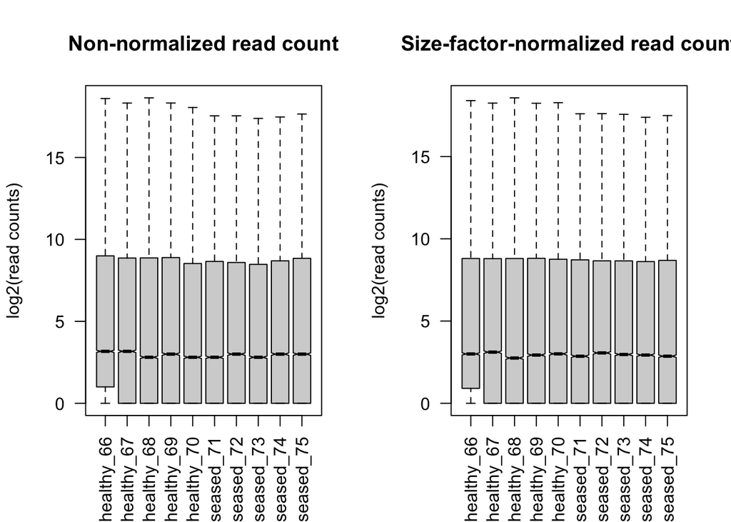

**Figure 3:** *Size Factor Normalization*

```r
# Calculate size factors and add them to object
DESeq.ds <- estimateSizeFactors(DESeq.ds)
# Transform the normalized read counts to bring them onto similar scales
par(mfrow=c(1,2)) # to plot the two box plots next to each other
# Boxplot of non-normalized
boxplot(log2(counts(DESeq.ds) +1), notch=TRUE,
        main = "Non-normalized read count",
        ylab ="log2(read counts)", cex = .6, las = 2)
# Boxplot of size-factor normalized values
boxplot(log2(counts(DESeq.ds, normalized=TRUE) +1), notch=TRUE,
        main = "Size-factor-normalized read count",
        ylab ="log2(read counts)", cex = .6, las = 2)
```

# Accounting for Heteroskedasticity and Large Dynamic Range

We can then further process the data. First a pair of healthy and a pair of diseased individuals are visualized by comparing their log normalized counts against one other, (refer to Figure 4) wherein each dot is one gene, and we can note that the points fan out towards the lower left corner. This means that lower read counts correlate worse between replicates. This means that the standard deviation of the expression levels likely depends on the mean.

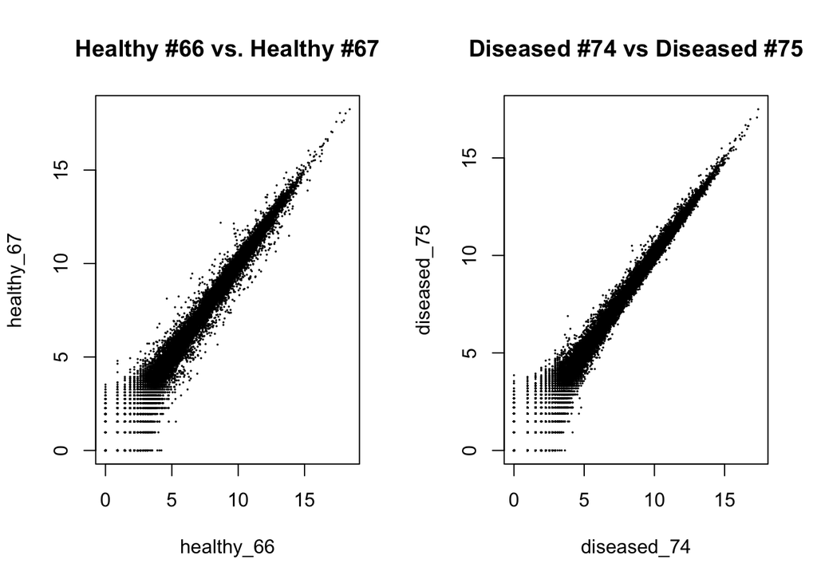

**Figure 4:** *Healthy vs. Diseased Pairs*

```r
## non-normalized read counts plus pseudocount
log.counts <- log2(counts(DESeq.ds, normalized = FALSE) + 1)

## instead of creating a new object, we could assign the values to a distinct matrix
## within the DESeq.ds object
assay(DESeq.ds, "log.counts") <- log2(counts(DESeq.ds, normalized = FALSE) + 1)
## normalized read counts
assay(DESeq.ds, "log.norm.counts") <- log2(counts(DESeq.ds, normalized=TRUE) + 1)
par(mfrow=c(1,2))
DESeq.ds[, c("healthy_66","healthy_67")] %>%
  assay(.,  "log.norm.counts") %>%
  plot(., cex=.1, main = "Healthy #66 vs. Healthy #67")
DESeq.ds[, c("diseased_74","diseased_75")] %>%
  assay(.,  "log.norm.counts") %>%
  plot(., cex=.1, main = "Diseased #74 vs Diseased #75")
```

This can be better visualized through a `meanSdPlot` (see Figure 5) where the red line shows the running median estimator and it should be horizontal to indicate that there is no variance-mean dependence. As we can observe in the plot, we see that the data exhibits heteroskedasticity (i.e. there is some variance-mean dependence for genes with low read counts). In order to continue with the analysis, as many tools assume homoskedastic data, we must rectify this.

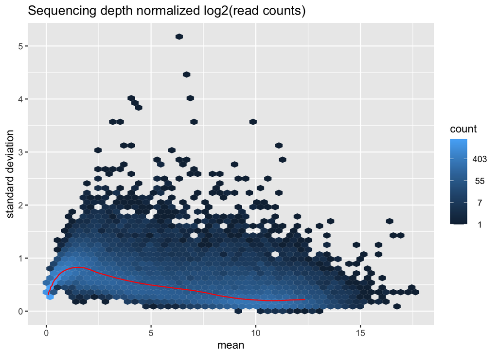

**Figure 5:** *meanSdPlot*

```r
#BiocManager::install("vsn")
## generate the base meanSdPlot using sequencing depth normalized log2(read counts) ## set up plotting frame
par(mfrow=c(1,1))
## generate the plot
msd_plot <- vsn::meanSdPlot(assay(DESeq.ds, "log.norm.counts"), ranks=FALSE, # show the data on the original scale
plot = FALSE)
## since vsn::meanSdPlot generates a ggplot2 object, this can be manipulated in the usual ways
msd_plot$gg +
  ggtitle("Sequencing depth normalized log2(read counts)") +
  ylab("standard deviation")
```

To reduce the dependence of the variance on the mean we can use `rlog` and `varianceStabilizingTransformation (vst)`. This yields a much more horizontal line and greatly reduces heteroskedasticity (see Figure 6). The objects created were stored on the disk for future analysis via `save.image()`.

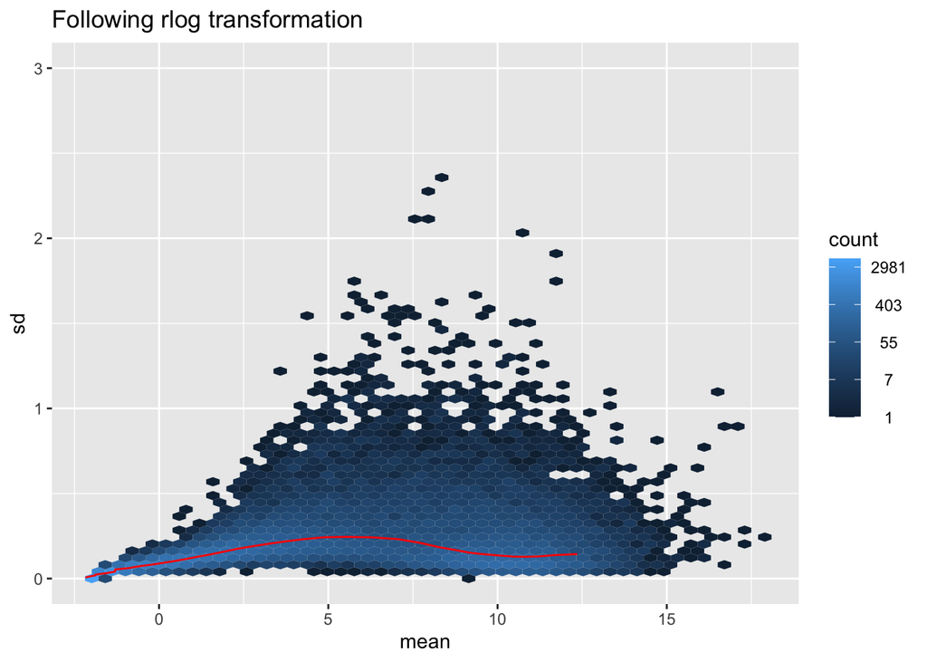

**Figure 6:** *meanSdPlot after Correction*

```r
DESeq.rlog <- rlog(DESeq.ds, blind = TRUE)
rlog.norm.counts <- assay(DESeq.rlog)
## rlog-transformed read counts
msd_plot <- vsn::meanSdPlot(assay(DESeq.rlog), ranks=FALSE, plot = FALSE)
msd_plot$gg + ggtitle("Following rlog transformation") +
  coord_cartesian(ylim = c(0,3))
```

```r
#save.image(file = "~/Desktop/RNA_data.RData")
```

At the end of this procedure, we have expression values that are adjusted for differences in sequencing depth, differences in RNA composition, heteroskadasticity, and large dynamic range.

# IX. Performing Differential Gene Expression Analysis

```r
#FILE_DSD="~/Desktop/RNA_data.RData"
#load(FILE_DSD)
DESeq.ds$condition #baseline check, make sure control in right place
```

```
##  [1] healthy  healthy  healthy  healthy  healthy  diseased diseased diseased
##  [9] diseased diseased
## Levels: diseased healthy
```

```r
design(DESeq.ds)
```

```
## ~condition
```

```r
DESeq.ds %<>% DESeq()
DESeq.ds
```

```
## class: DESeqDataSet
## dim: 37309 10
## metadata(1): version
## assays(6): counts log.counts ... H cooks
## rownames(37309): TRNP TRNT ... MIR6859.1 WASH7P
## rowData names(22): baseMean baseVar ... deviance maxCooks
## colnames(10): healthy_66 healthy_67 ... diseased_74 diseased_75
## colData names(2): condition sizeFactor
```

```r
rowData(DESeq.ds) %>% colnames
```

```
##  [1] "baseMean"
##  [2] "baseVar"
##  [3] "allZero"
##  [4] "dispGeneEst"
##  [5] "dispGeneIter"
##  [6] "dispFit"
##  [7] "dispersion"
##  [8] "dispIter"
##  [9] "dispOutlier"
## [10] "dispMAP"
## [11] "Intercept"
## [12] "condition_healthy_vs_diseased"
## [13] "SE_Intercept"
## [14] "SE_condition_healthy_vs_diseased"
## [15] "WaldStatistic_Intercept"
## [16] "WaldStatistic_condition_healthy_vs_diseased"
## [17] "WaldPvalue_Intercept"
## [18] "WaldPvalue_condition_healthy_vs_diseased"
## [19] "betaConv"
## [20] "betaIter"
## [21] "deviance"
## [22] "maxCooks"
```

Now, we can adjust for multiple hypothesis testing with independent filtering using. First, I visualized the raw distribution of p-values (see Figure 7) yielded in the rowData of the DESeq object under `WaldPvalue_condition_healthy_vs_diseased`.

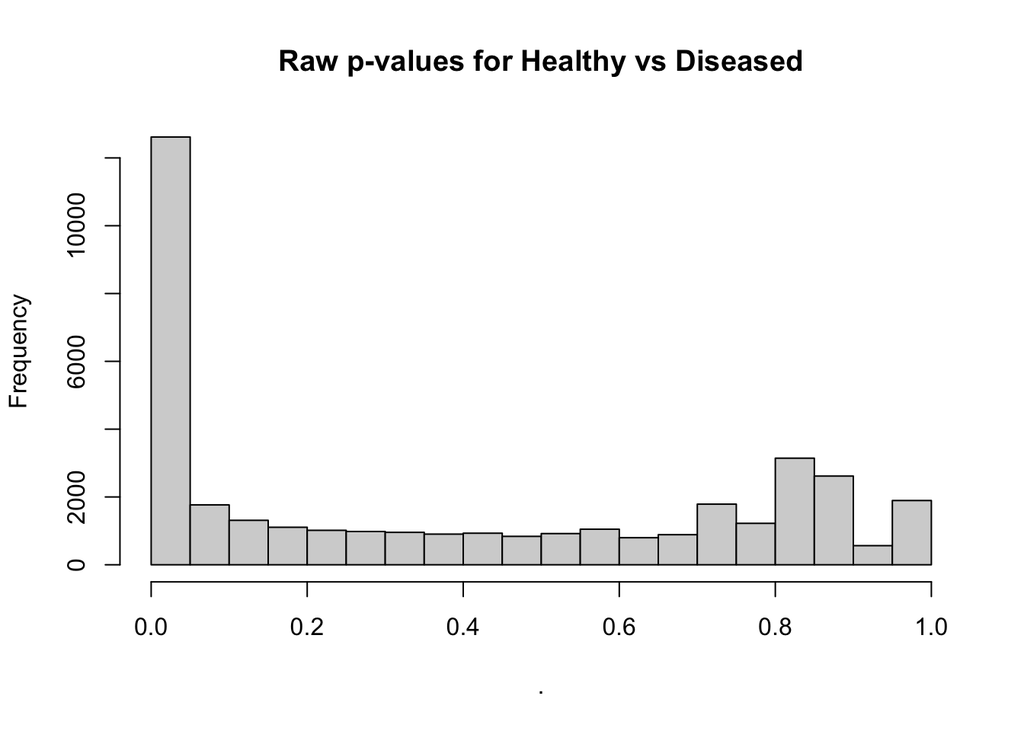

**Figure 7:** *Raw p-values for Healthy vs Diseased*

```r
rowData(DESeq.ds)$WaldPvalue_condition_healthy_vs_diseased %>%
    hist(breaks=19, main="Raw p-values for Healthy vs Diseased")
```

This can then be filtered using an alpha cutoff of 0.05 with `independentFiltering` to find the optimal expression cutoff to maximize the absolute number of genes that pass through the adjusted p-value threshold. After normalization we see a reduction in the outlier terms and a more even distribution.

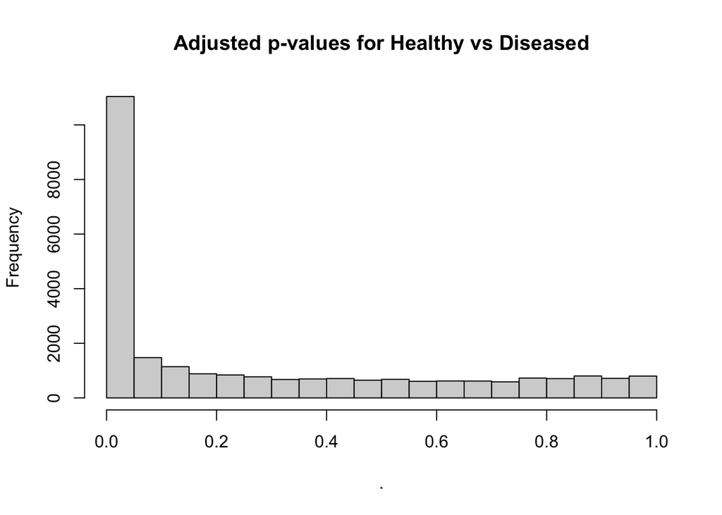

**Figure 8:** *Adjusted p-values for Healthy vs Diseased*

```r
DGE.results <- results(DESeq.ds, independentFiltering = TRUE, alpha = 0.05)
DGE.results$padj %>%
    hist(breaks=19, main="Adjusted p-values for Healthy vs Diseased")
```

Shrinkage is performed on the logFC estimates for lowly and noisily expressed genes towards zero, thus reducing their importance for any subsequent analyses downstream.

```r
#BiocManager::install("apeglm")
DGE.results <- lfcShrink(DESeq.ds, coef=2, type="apeglm")
```

```
## using 'apeglm' for LFC shrinkage. If used in published research, please cite:
##     Zhu, A., Ibrahim, J.G., Love, M.I. (2018) Heavy-tailed prior distributions for
##     sequence count data: removing the noise and preserving large differences.
##     Bioinformatics. https://doi.org/10.1093/bioinformatics/bty895
```

```r
# Use coef = 2 because second coefficient of resultsNames(DESeq.ds) is condition_healthy_vs_diseasedso expression of the genes will be based on these conditions
```

Now, I can sort my DGE.results to obtain some of the top hits with the lowest padj values. We can see by looking at the first 6 genes, some of them are relevant to our study. Figure9 shows the Mitochondrial Nuclear Retrograde Regulator 1 (CHCHD2), the X-inactive specific transcript (XIST), and ITGA8 which is important in cytoskeletal organization and cellular adhesion were all found the be relevant in the Corsi et al. paper that this data was downloaded from (further analysis to be done in the Results section).

```r
DGE.results.sorted <- DGE.results %>% `[`(order(.$padj),)
head(DGE.results.sorted)
```

```
## log2 fold change (MAP): condition healthy vs diseased
## Wald test p-value: condition healthy vs diseased
## DataFrame with 6 rows and 5 columns
##         baseMean log2FoldChange     lfcSE       pvalue         padj
##        <numeric>      <numeric> <numeric>    <numeric>    <numeric>
## FRZB    5109.924        2.69240  0.092265 2.89266e-188 7.65341e-184
## CFH     8829.775        5.29306  0.183375 2.13117e-184 2.81932e-180
## NID2    1931.987        3.09075  0.115008 3.19103e-160 2.81428e-156
## CHCHD2   380.582       -3.85386  0.147088 1.66613e-152 1.10206e-148
## XIST    1301.251       -9.97425  0.404533 9.96345e-133 5.27226e-129
## ITGA8   1878.606        4.09872  0.168886 3.00977e-131 1.32721e-127
```

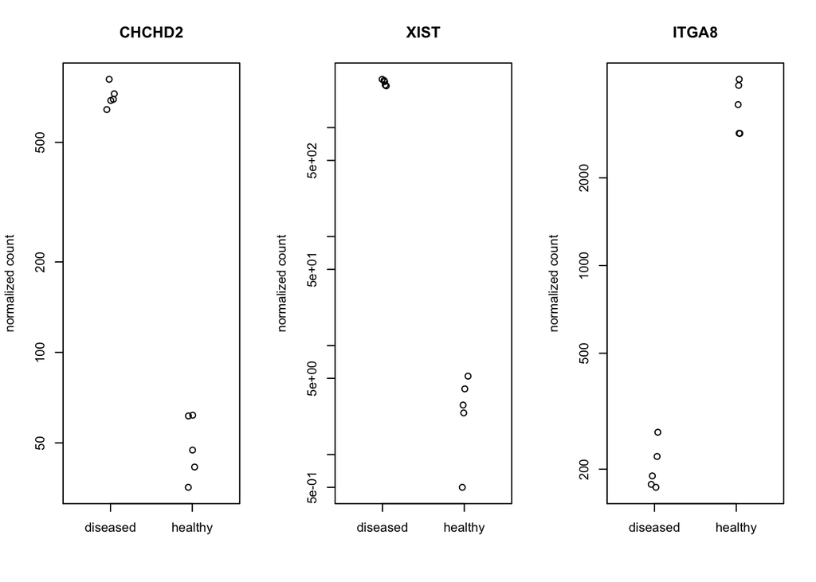

**Figure 9:** *plotCounts for Differentially Expressed Genes*

```r
par(mfrow=c(1,3))
plotCounts(DESeq.ds, gene="CHCHD2", normalized = TRUE, xlab="")
plotCounts(DESeq.ds, gene="XIST", normalized = TRUE, xlab="")
plotCounts(DESeq.ds, gene="ITGA8", normalized = TRUE, xlab="")
```

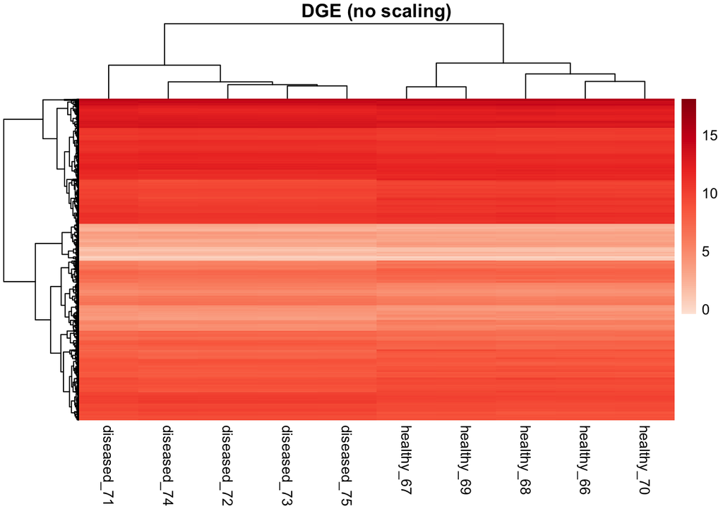

**Figure 10:** *Heatmap (No Scaling)*

```r
# identify genes with the desired adjusted p-value cut-off
DGEgenes <- rownames(subset(DGE.results.sorted, padj < 0.05)) # extract rlog-transformed values into a matrix
rlog.dge <- DESeq.rlog[DGEgenes,] %>% assay
# heatmap of DEG sorted by p.adjust
pheatmap(rlog.dge, scale="none",
         show_rownames=FALSE, main="DGE (no scaling)",
         color=colorRampPalette(RColorBrewer::brewer.pal(n=7, name="Reds"))(100)
)
```

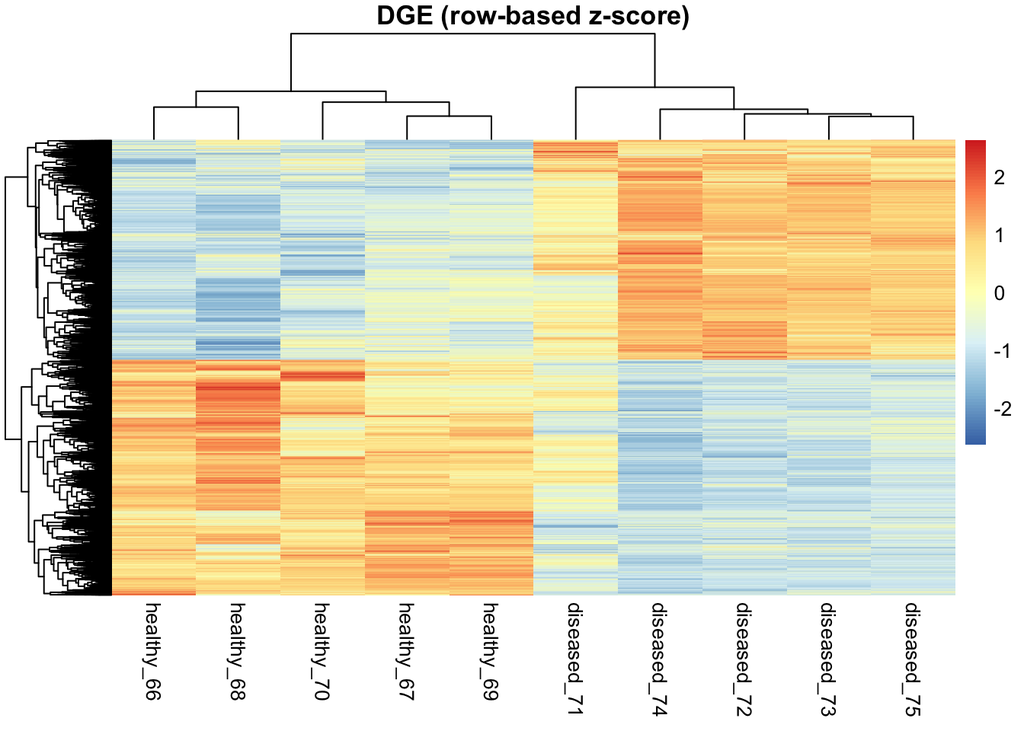

**Figure 11:** *Heatmap of DGE(row-based z-score)*

```r
pheatmap(rlog.dge, scale="row",
         show_rownames=FALSE, main="DGE (row-based z-score)")
```

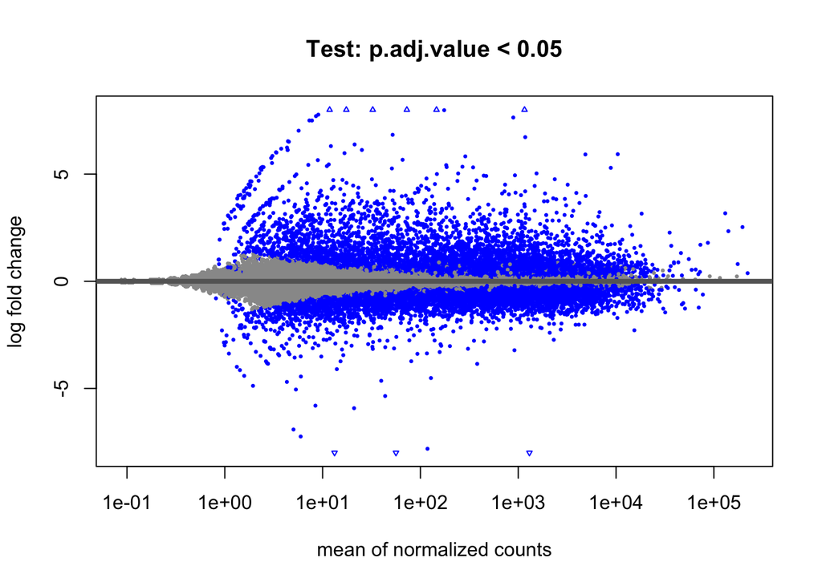

**Figure 12:** *MA plot*

```r
plotMA(DGE.results, alpha=0.05,
      main="Test: p.adj.value < 0.05", ylim = c(-8,8))
```

We can also make a volcano plot which also serves to provide a visual representation of the differential expression analysis results. We see the log2 full change on the x axis and the -log(p) values on the y axis. This means that the values in the top right and top left of the plot are of most interest as they exhibit a higher fold change and low p value, making them differentially expressed genes of interest.

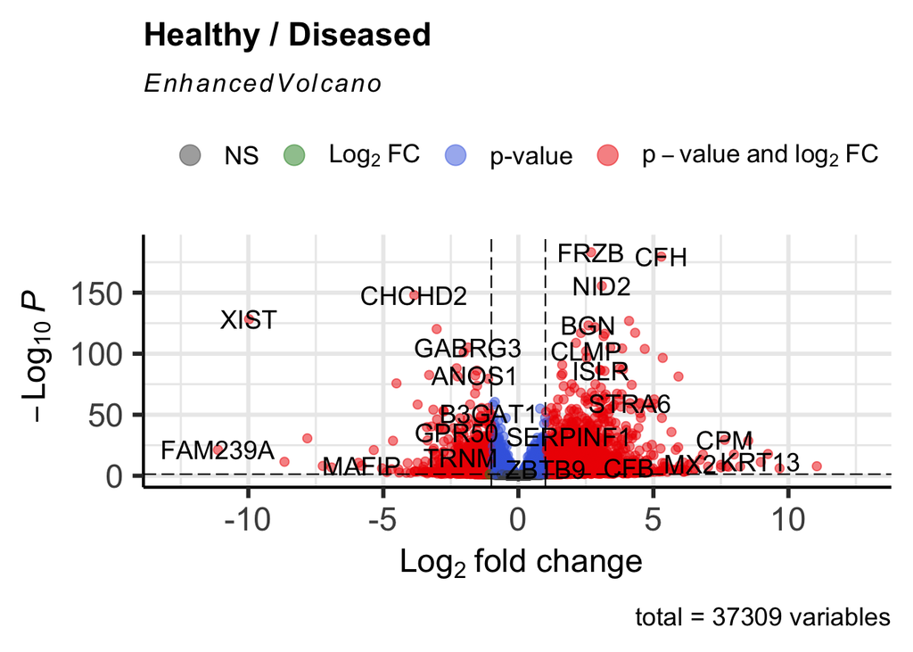

**Figure 13:** *Volcano Plot*

```r
vp1 <- EnhancedVolcano(DGE.results,
                       lab=rownames(DGE.results),
                      x='log2FoldChange', y='padj',
                      pCutoff=0.05,
                      title="Healthy / Diseased")
print(vp1)
```

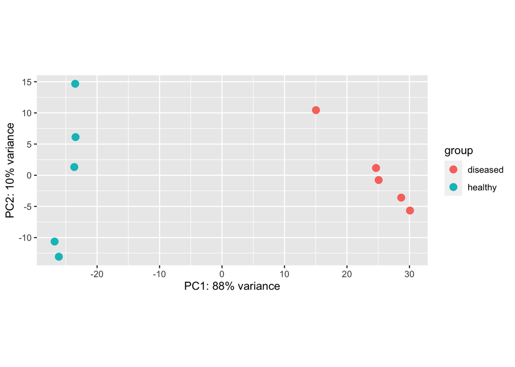

**Figure 14:** *PCA*

```r
plotPCA(rlog(DESeq.ds, blind = FALSE), intgroup=c("condition"))
```

The GO enrichments were done for all categories: Biological Process (BP), Molecular Function (MF) and Cellular Component (CC).

```r
# Load the required libraries
library(clusterProfiler)
library(org.Hs.eg.db) # or the appropriate organism database

# Run DESeq2 analysis and extract differentially expressed genes
DESeq.ds <- DESeq(DESeq.ds)
```

```
## found already estimated dispersions, replacing these
```

```r
DGE.results <- results(DESeq.ds, independentFiltering = TRUE, alpha = 0.05)
num_genes <- length(rownames(subset(DGE.results, padj < 0.05 & abs(log2FoldChange) >= 1.0))) # 1.0 for twofold
write.table(DGE.results, file = "DGE_Table.txt", row.names = TRUE, col.names = TRUE)
cat("Total Number of Differentially Expressed Genes with Padj < 0.05 and Two-Fold Change:\n", num_genes, "\n")
```

```
## Total Number of Differentially Expressed Genes with Padj < 0.05 and Two-Fold Change:
##  4154
```

```r
DGE.genes <- rownames(subset(DGE.results, padj < 0.05 & abs(log2FoldChange) >= 2.0)) # 1.0 for twofold
cat("Subset of Genes for GO Enrichment:\n", length(DGE.genes))
```

```
## Subset of Genes for GO Enrichment:
##  1371
```

```r
#head(DGE.genes)
# Convert differentially expressed genes to a vector
gene.vector <- row.names(DGE.results) %in% DGE.genes %>% as.integer #can be sorted
names(gene.vector) <- row.names(DGE.results) #can be sorted
```

```r
go_enrichment_BP <- enrichGO(gene = names(which(gene.vector == 1)),
                             'org.Hs.eg.db',
                             keyType = "SYMBOL",
                             ont = "BP",
                             pvalueCutoff = 0.01,
                             qvalueCutoff = 0.05)
cat("Top 6 enrichment pathways for BP\n")
```

```
## Top 6 enrichment pathways for BP
```

```r
head(go_enrichment_BP@result$Description)
```

```
## [1] "extracellular matrix organization"
## [2] "extracellular structure organization"
## [3] "external encapsulating structure organization"
## [4] "embryonic organ morphogenesis"
## [5] "embryonic organ development"
## [6] "ear morphogenesis"
```

```r
cat("\n")
```

```r
go_enrichment_CC <- enrichGO(gene = names(which(gene.vector == 1)),
                             'org.Hs.eg.db',
                             keyType = "SYMBOL",
                             ont = "CC",
                             pvalueCutoff = 0.01,
                             qvalueCutoff = 0.05)
cat("Top 6 enrichment pathways for CC\n")
```

```
## Top 6 enrichment pathways for CC
```

```r
head(go_enrichment_CC@result$Description)
```

```
## [1] "collagen-containing extracellular matrix"
## [2] "collagen trimer"
## [3] "endoplasmic reticulum lumen"
## [4] "basement membrane"
## [5] "external side of plasma membrane"
## [6] "complex of collagen trimers"
```

```r
cat("\n")
```

```r
go_enrichment_MF <- enrichGO(gene = names(which(gene.vector == 1)),
                             'org.Hs.eg.db',
                             keyType = "SYMBOL",
                             ont = "MF",
                             pvalueCutoff = 0.01,
                             qvalueCutoff = 0.05)
cat("Top 6 enrichment pathways for MF\n")
```

```
## Top 6 enrichment pathways for MF
```

```r
head(go_enrichment_MF@result$Description)
```

```
## [1] "extracellular matrix structural constituent"
## [2] "extracellular matrix structural constituent conferring tensile strength"
## [3] "glycosaminoglycan binding"
## [4] "receptor ligand activity"
## [5] "signaling receptor activator activity"
## [6] "heparin binding"
```

```r
cat("\n")
```

```r
write.table(head(go_enrichment_BP@result$Description), file = "BP_enrichment.txt", sep = "\t")
write.table(head(go_enrichment_CC@result$Description), file = "CC_enrichment.txt", sep = "\t")
write.table(head(go_enrichment_MF@result$Description), file = "MF_enrichment.txt", sep = "\t")
```